# SOC2069 Researching Social Life 1

Analysing qualitative data

Dr. Chris Moreh

## Outline

1. What is qualitative data analysis?
2. Themes and coding
3. Software options for QDA

What is qualitative data analysis?

1 2 3 4

## Qualitative data analysis

1 2 3 4

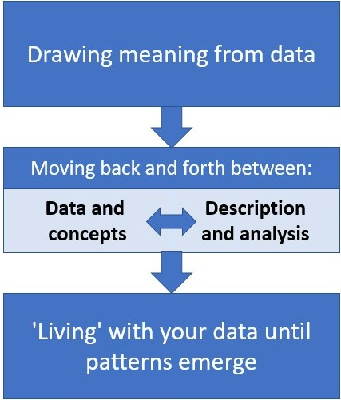

> We have two tasks after we have gathered our data, namely to reduce our data to something we can manage, and to analyze our data in meaningful ways (**Luker 2008: 198-199**)

> Analysis involves a constant moving back and forward between the entire data set, the coded extracts of data that you are analysing, and the analysis of the data that you are producing (**Braun and Clarke**)

> As we contemplate that first interview, or set of field notes, or focus group experience, or day in the archives, we need to remind ourselves that our most important job today (and all subsequent days) is pattern recognition (**Luker 2008: 199**)

## Finding themes

1 2 3 4

1. Familiarize yourself with your data
2. Assign preliminary codes to your data in order to describe the content
3. Search for patterns or themes in your codes across the different interviews
4. Review themes
5. Define and name themes
6. Produce your report

## Coding

[figure not shown]